# Explore_bikeshare_data

### Explore Bike Share Data

For this project, your goal is to ask and answer three questions about the available bikeshare data from Washington, Chicago, and New York. This notebook can be submitted directly through the workspace when you are confident in your results.

```r
library(ggplot2)
library(dplyr)
library(lubridate)

# Loading in datasets
ny = read.csv('new_york_city.csv')
wash = read.csv('washington.csv')
chi = read.csv('chicago.csv')
```

```r
# Viewing ny df
head(ny)
```

| X | Start.Time | End.Time | Trip.Duration | Start.Station | End.Station | User.Type | Gender | Birth.Year |
| --- | --- | --- | --- | --- | --- | --- | --- | --- |
| 5688089 | 2017-06-11 14:55:05 | 2017-06-11 15:08:21 | 795 | Suffolk St & Stanton St | W Broadway & Spring St | Subscriber | Male | 1998 |
| 4096714 | 2017-05-11 15:30:11 | 2017-05-11 15:41:43 | 692 | Lexington Ave & E 63 St | 1 Ave & E 78 St | Subscriber | Male | 1981 |
| 2173887 | 2017-03-29 13:26:26 | 2017-03-29 13:48:31 | 1325 | 1 Pl & Clinton St | Henry St & Degraw St | Subscriber | Male | 1987 |
| 3945638 | 2017-05-08 19:47:18 | 2017-05-08 19:59:01 | 703 | Barrow St & Hudson St | W 20 St & 8 Ave | Subscriber | Female | 1986 |
| 6208972 | 2017-06-21 07:49:16 | 2017-06-21 07:54:46 | 329 | 1 Ave & E 44 St | E 53 St & 3 Ave | Subscriber | Male | 1992 |
| 1285652 | 2017-02-22 18:55:24 | 2017-02-22 19:12:03 | 998 | State St & Smith St | Bond St & Fulton St | Subscriber | Male | 1986 |

```r
# Getting rows/columns of ny df
dim(ny)
```

1. 54770

2. 9

```r
# Viewing column names
names(ny)
```

1. 'X'

2. 'Start.Time'

3. 'End.Time'

4. 'Trip.Duration'

5. 'Start.Station'

6. 'End.Station'

7. 'User.Type'

8. 'Gender'

9. 'Birth.Year'

```r
# Viewing washington df
head(wash)
```

| X | Start.Time | End.Time | Trip.Duration | Start.Station | End.Station | User.Type |
| --- | --- | --- | --- | --- | --- | --- |
| 1621326 | 2017-06-21 08:36:34 | 2017-06-21 08:44:43 | 489.066 | 14th & Belmont St NW | 15th & K St NW | Subscriber |
| 482740 | 2017-03-11 10:40:00 | 2017-03-11 10:46:00 | 402.549 | Yuma St & Tenley Circle NW | Connecticut Ave & Yuma St NW | Subscriber |
| 1330037 | 2017-05-30 01:02:59 | 2017-05-30 01:13:37 | 637.251 | 17th St & Massachusetts Ave NW | 5th & K St NW | Subscriber |
| 665458 | 2017-04-02 07:48:35 | 2017-04-02 08:19:03 | 1827.341 | Constitution Ave & 2nd St NW/DOL | M St & Pennsylvania Ave NW | Customer |
| 1481135 | 2017-06-10 08:36:28 | 2017-06-10 09:02:17 | 1549.427 | Henry Bacon Dr & Lincoln Memorial Circle NW | Maine Ave & 7th St SW | Subscriber |
| 1148202 | 2017-05-14 07:18:18 | 2017-05-14 07:24:56 | 398.000 | 1st & K St SE | Eastern Market Metro / Pennsylvania Ave & 7th St SE | Subscriber |

```r
# Getting rows/columns of wash df
dim(wash)
```

1. 89051

2. 7

```r
# Viewing column names
names(wash)
```

1. 'X'

2. 'Start.Time'

3. 'End.Time'

4. 'Trip.Duration'

5. 'Start.Station'

6. 'End.Station'

7. 'User.Type'

```r
# Viewing Chicago Dataset
head(chi)
```

| X | Start.Time | End.Time | Trip.Duration | Start.Station | End.Station | User.Type | Gender | Birth.Year |
| --- | --- | --- | --- | --- | --- | --- | --- | --- |
| 1423854 | 2017-06-23 15:09:32 | 2017-06-23 15:14:53 | 321 | Wood St & Hubbard St | Damen Ave & Chicago Ave | Subscriber | Male | 1992 |
| 955915 | 2017-05-25 18:19:03 | 2017-05-25 18:45:53 | 1610 | Theater on the Lake | Sheffield Ave & Waveland Ave | Subscriber | Female | 1992 |
| 9031 | 2017-01-04 08:27:49 | 2017-01-04 08:34:45 | 416 | May St & Taylor St | Wood St & Taylor St | Subscriber | Male | 1981 |
| 304487 | 2017-03-06 13:49:38 | 2017-03-06 13:55:28 | 350 | Christiana Ave & Lawrence Ave | St. Louis Ave & Balmoral Ave | Subscriber | Male | 1986 |
| 45207 | 2017-01-17 14:53:07 | 2017-01-17 15:02:01 | 534 | Clark St & Randolph St | Desplaines St & Jackson Blvd | Subscriber | Male | 1975 |
| 1473887 | 2017-06-26 09:01:20 | 2017-06-26 09:11:06 | 586 | Clinton St & Washington Blvd | Canal St & Taylor St | Subscriber | Male | 1990 |

```r
# Getting numbers rows/columns of chicago dataset
dim(chi)
```

1. 8630

2. 9

```r
# Viewing column names in chi dataset
names(chi)
```

1. 'X'

2. 'Start.Time'

3. 'End.Time'

4. 'Trip.Duration'

5. 'Start.Station'

6. 'End.Station'

7. 'User.Type'

8. 'Gender'

9. 'Birth.Year'

```r
# Preparing datasets to concatenate
# Creating 'Gender' & 'Birth.Year' columns in wash df and filling with NA
wash$Gender = 'NA'
wash$Birth.Year = 'NA'

# Creating 'City' columns and filling with city values
wash$City = 'Washington'
ny$City = 'New York City'
chi$City = 'Chicago'
```

```r
# Concatenate 3 datasets
df <- rbind(ny, wash, chi)
head(df)
```

| X | Start.Time | End.Time | Trip.Duration | Start.Station | End.Station | User.Type | Gender | Birth.Year | City |
| --- | --- | --- | --- | --- | --- | --- | --- | --- | --- |
| 5688089 | 2017-06-11 14:55:05 | 2017-06-11 15:08:21 | 795 | Suffolk St & Stanton St | W Broadway & Spring St | Subscriber | Male | 1998 | New York City |
| 4096714 | 2017-05-11 15:30:11 | 2017-05-11 15:41:43 | 692 | Lexington Ave & E 63 St | 1 Ave & E 78 St | Subscriber | Male | 1981 | New York City |
| 2173887 | 2017-03-29 13:26:26 | 2017-03-29 13:48:31 | 1325 | 1 Pl & Clinton St | Henry St & Degraw St | Subscriber | Male | 1987 | New York City |
| 3945638 | 2017-05-08 19:47:18 | 2017-05-08 19:59:01 | 703 | Barrow St & Hudson St | W 20 St & 8 Ave | Subscriber | Female | 1986 | New York City |
| 6208972 | 2017-06-21 07:49:16 | 2017-06-21 07:54:46 | 329 | 1 Ave & E 44 St | E 53 St & 3 Ave | Subscriber | Male | 1992 | New York City |
| 1285652 | 2017-02-22 18:55:24 | 2017-02-22 19:12:03 | 998 | State St & Smith St | Bond St & Fulton St | Subscriber | Male | 1986 | New York City |

```r
# Checking dimensions of new concatenated df
dim(df)
```

1. 152451

2. 10

```r
# Viewing datatypes of df columns
str(df)
```

```
'data.frame':	152451 obs. of  10 variables:
 $ X            : int  5688089 4096714 2173887 3945638 6208972 1285652 1675753 1692245 2271331 1558339 ...
 $ Start.Time   : Factor w/ 143945 levels "2017-01-01 00:17:01",..: 45448 32799 17316 31589 49688 10220 13390 13509 18111 12449 ...
 $ End.Time     : Factor w/ 143948 levels "201","2017-01-01 00:30:56",..: 45432 32783 17295 31567 49668 10204 13364 13505 18092 12422 ...
 $ Trip.Duration: num  795 692 1325 703 329 ...
 $ Start.Station: Factor w/ 1585 levels "","1 Ave & E 16 St",..: 522 406 10 93 5 521 325 309 151 245 ...
 $ End.Station  : Factor w/ 1586 levels "","1 Ave & E 16 St",..: 613 8 362 558 269 107 389 110 151 243 ...
 $ User.Type    : Factor w/ 3 levels "","Customer",..: 3 3 3 3 3 3 3 3 2 3 ...
 $ Gender       : Factor w/ 4 levels "","Female","Male",..: 3 3 3 2 3 3 3 3 1 3 ...
 $ Birth.Year   : chr  "1998" "1981" "1987" "1986" ...
 $ City         : chr  "New York City" "New York City" "New York City" "New York City" ...
```

### Question 1

What are the average Trip Durations in each city?

```r
# Trip duration in seconds - create function by city
City.Trip.Duration = function(City){
    if (City == "New York City")
        return(mean(df[df$City == "New York City", 'Trip.Duration'], na.rm = TRUE))
    else if (City == "Washington")
        return(mean(df[df$City == "Washington", 'Trip.Duration'], na.rm = TRUE))
    else
        return(mean(df[df$City == "Chicago", 'Trip.Duration'], na.rm = TRUE))
}
```

```r
# Getting average trip duration in seconds by city

# NYC Trip Duration Mean calling function
NY.Duration.Mean = City.Trip.Duration('New York City')
# Chicago Trip Duration Mean calling function
Chi.Duration.Mean = City.Trip.Duration('Chicago')
# Wash Trip Duration Mean calling function
Wash.Duration.Mean = City.Trip.Duration('Washington')

print(round(Chi.Duration.Mean))
print(round(NY.Duration.Mean))
print(round(Wash.Duration.Mean))
```

```
[1] 937
[1] 904
[1] 1234
```

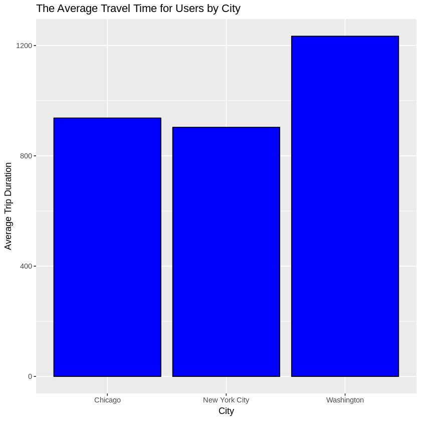

```r
# Bar graph of average trip duration by city
ggplot(aes(x = City, y = Trip.Duration), data = df) +
    geom_bar(position = 'stack', stat = "summary", fun.y = "mean", fill = "blue", color="black") +
    ggtitle('The Average Travel Time for Users by City') +
    labs(y = 'Average Trip Duration', x = 'City')
```

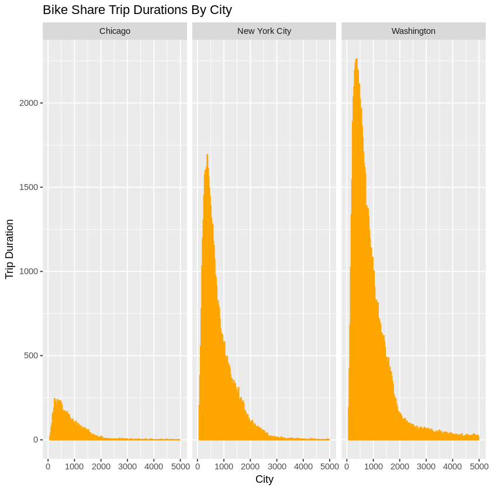

```r
# Histogram of Trip Duration by City
ggplot(aes(x=Trip.Duration), data=df) +
      geom_histogram(binwidth = 25, color="orange") +
      scale_x_continuous(limits = c(50, 5000), breaks = seq(0, 5000, 1000))+
      facet_wrap(~City) +
      ggtitle('Bike Share Trip Durations By City') +
      labs(y = 'Trip Duration', x = 'City')
```

```r
# Summary of Trip Durations by City
by(df$Trip.Duration, df$City, summary)
```

```
df$City: Chicago
   Min. 1st Qu.  Median    Mean 3rd Qu.    Max.
   60.0   394.2   670.0   937.2  1119.0 85408.0
------------------------------------------------------------
df$City: New York City
     Min.   1st Qu.    Median      Mean   3rd Qu.      Max.      NA's
     61.0     368.0     610.0     903.6    1051.0 1088634.0         1
------------------------------------------------------------
df$City: Washington
    Min.  1st Qu.   Median     Mean  3rd Qu.     Max.     NA's
    60.3    410.9    707.0   1234.0   1233.2 904591.4        1
```

### Question 1 Summary

Based on the above bar graph, the average trip duration per bike share users among all three cities appears to be similar, with New York City and Chicago having average bike trip durations at 904 seconds and 937 seconds, respectively. Washington appears to have the longest average bike trip durations among users at 1234 seconds.

Looking further into the data summaries and data spread via histograms, we see all three cities have right skewed tails, indicating some users have much longer bike trips. The max bike trip for New York City was 1,088,634 seconds while the max bike trip for Washington was 904,591 seconds. Both are significantly longer than the max bike trip duration for Chicago of 85408 seconds. Another insight noted from viewing the histogram spread of bike share trip duration data is there are significantly more users in New York and Washington than there are in Chicago.

### Question 2

How do Trip Durations differ among Bike Share User Types?

```r
# Number of User Types by City
by(df$User.Type, df$City, summary)
```

```
df$City: Chicago
             Customer Subscriber
         1       1746       6883
------------------------------------------------------------
df$City: New York City
             Customer Subscriber
       119       5558      49093
------------------------------------------------------------
df$City: Washington
             Customer Subscriber
         1      23450      65600
```

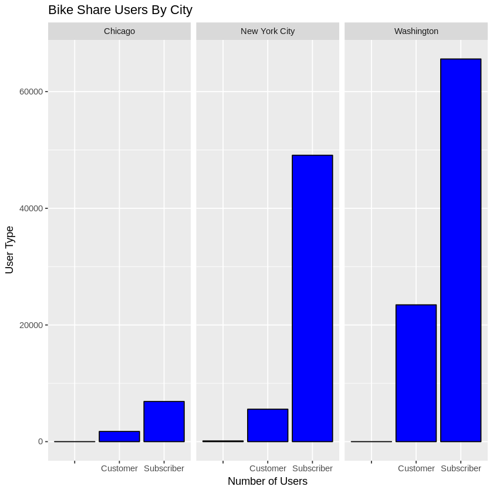

```r
# Bar plot depicting number of Subscribers and Users by City
ggplot(df, aes(x = User.Type)) +
    geom_bar(stat = 'count', fill = "blue", color="black") +
    facet_wrap(~City) +
    ggtitle('Bike Share Users By City') +
      labs(y = 'User Type', x = 'Number of Users')
```

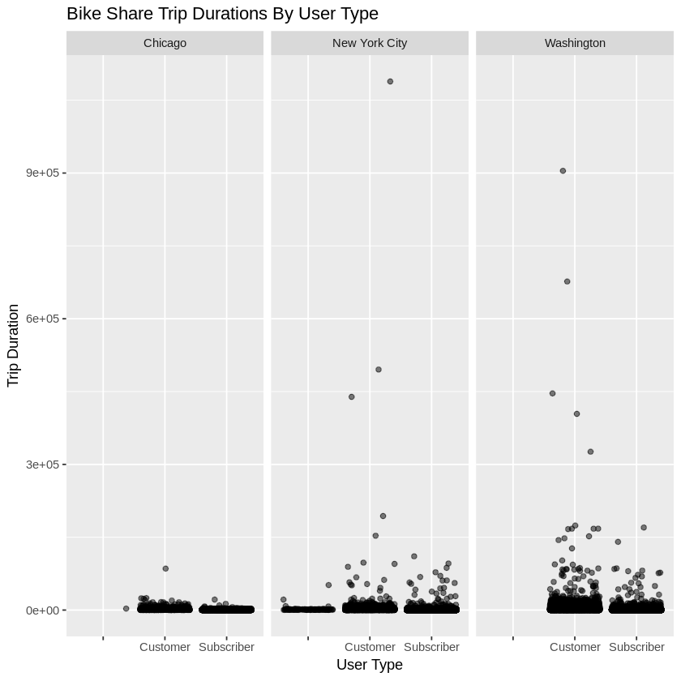

```r
# Scatterplot depicting Trip Durations by User Type
ggplot(df, aes(x = User.Type, y = Trip.Duration)) +
    geom_jitter(alpha = 0.5) +
    facet_wrap(~City) +
    ggtitle('Bike Share Trip Durations By User Type') +
      labs(x = 'User Type', y = 'Trip Duration')
```

```r
# Summary of Bike Share Trip Durations by User Type
by(df$Trip.Duration, list(df$User.Type), summary)
```

```
:
   Min. 1st Qu.  Median    Mean 3rd Qu.    Max.    NA's
    201     764    1112    1848    1536   51595       2
------------------------------------------------------------
: Customer
     Min.   1st Qu.    Median      Mean   3rd Qu.      Max.
     61.3     915.4    1450.0    2514.7    2404.5 1088634.0
------------------------------------------------------------
: Subscriber
    Min.  1st Qu.   Median     Mean  3rd Qu.     Max.
    60.0    352.2    567.5    739.5    914.7 170032.9
```

### Question 2 Summary

According to the summary information and the above bar graph, there are more subscribed bike share users than there are bike share customers in all three cities.

When observing the relationship of trip durations by user types between all three cities, it appears bike share customers have longer trip durations than subscribers. The mean trip duration for subscribers is approximately 740 seconds while the mean trip duration for customers is approximately 2515 seconds.

### Question 3

How do Bike Share User Types differ over the days of the week?

```r
# Converting str into datetime data type
# Source for datetime in r: https://r4ds.had.co.nz/dates-and-times.html

dt_start <- ymd_hms(df$Start.Time)
df$Weekday <- wday(dt_start, label=TRUE, abbr=FALSE)
```

```r
# Summary of User Types per Days of the Week
by(df$Weekday, df$User.Type, summary)
```

```
df$User.Type:
   Sunday    Monday   Tuesday Wednesday  Thursday    Friday  Saturday      NA's
       21        20         7        10        20         9        33         1
------------------------------------------------------------
df$User.Type: Customer
   Sunday    Monday   Tuesday Wednesday  Thursday    Friday  Saturday
     6904      3426      3033      3123      3159      3999      7110
------------------------------------------------------------
df$User.Type: Subscriber
   Sunday    Monday   Tuesday Wednesday  Thursday    Friday  Saturday
    12349     17147     19438     21947     20008     18371     12316
```

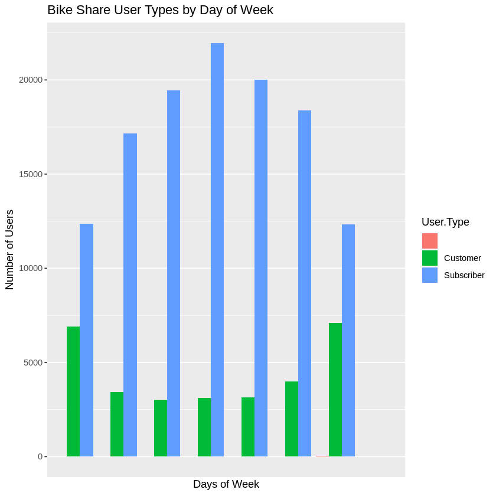

```r
# Plotting User Types by Days of the Week
ggplot(df, aes(x=Weekday, fill=User.Type)) +
    geom_bar(position = 'dodge', stat='count') +
    scale_x_discrete(breaks = c(1,2,3,4,5,6,7), labels = c('Sun', 'Mon', 'Tues', 'Wed', 'Thurs', 'Fri', 'Sat')) +
    labs(y = 'Number of Users', x = 'Days of Week') +
    ggtitle('Bike Share User Types by Day of Week')
```

### Question 3 Summary

The above graph represents the number of bike share users using the bike share service by days of the week. It appears bike share Subscribers use the bike share services more on typical work days, Monday through Friday, with the greatests amount of bike share Subscribers using the service on Wednesdays. Conversely, bike share Customers appear to use the services most on the weekends, days Saturday and Sunday, and do not appear to use the bike share service as much throughout the week when compared to Subscribers. This may suggest most bike share Subscribers utilize the service for occupational transportation purposes while bike share Customers utilize the service for recreation.

## Finishing Up

> Congratulations! You have reached the end of the Explore Bikeshare Data Project. You should be very proud of all you have accomplished!

> **Tip**: Once you are satisfied with your work here, check over your report to make sure that it is satisfies all the areas of the [rubric](https://review.udacity.com/#!/rubrics/2508/view).

## Directions to Submit

> Before you submit your project, you need to create a .html or .pdf version of this notebook in the workspace here. To do that, run the code cell below. If it worked correctly, you should get a return code of 0, and you should see the generated .html file in the workspace directory (click on the orange Jupyter icon in the upper left).

> Alternatively, you can download this report as .html via the **File** > **Download as** submenu, and then manually upload it into the workspace directory by clicking on the orange Jupyter icon in the upper left, then using the Upload button.

> Once you've done this, you can submit your project by clicking on the "Submit Project" button in the lower right here. This will create and submit a zip file with this .ipynb doc and the .html or .pdf version you created. Congratulations!

```r
system('python -m nbconvert Explore_bikeshare_data.ipynb')
```